# Analysis blinding with vazul: a walkthrough

Blind analysis workshop, part 3

## What this is

Run this document alongside the presentation. Every chunk is meant to be executed, changed, and executed again. By the end you should be able to answer one question about any blinding decision:

> **After this transformation, which analyses still give the right answer, and which ones no longer can?**

That question is the whole subject. The functions are easy; knowing what you have destroyed is the skill.

```r
library(vazul)
library(dplyr)
library(ggplot2)

theme_set(theme_light())
```

We use the `williams` dataset here, which ships with `vazul`. It is small and easy to eyeball: a two-group experiment where participants rated a target person after being told the target lived in a “Desperate” or a “Hopeful” ecology.

```r
data(williams)

glimpse(williams)
```

```
Rows: 112
Columns: 25
$ subject             <chr> "A30MP4LXV4MIFD", "A16X5FB3HAFCKN", "A1E9D1OT9VJYD~
$ SexUnres_1          <dbl> 5, 7, 2, 5, 5, 5, 5, 4, 6, 4, 5, 3, 5, 6, 3, 6, 2,~
$ SexUnres_2          <dbl> 3, 7, 4, 4, 5, 6, 6, 6, 5, 4, 5, 2, 5, 3, 2, 3, 1,~
$ SexUnres_3          <dbl> 2, 7, 6, 5, 6, 6, 5, 5, 6, 4, 7, 3, 5, 3, 3, 6, 3,~
$ SexUnres_4_r        <dbl> 3, 4, 3, 3, 3, 3, 3, 2, 3, 1, 3, 3, 3, 2, 3, 3, 4,~
$ SexUnres_5_r        <dbl> 2, 2, 3, 3, 3, 2, 4, 3, 2, 1, 2, 2, 4, 6, 3, 1, 3,~
$ Impuls_1            <dbl> 3, 6, 3, 4, 5, 5, 5, 6, 6, 1, 6, 2, 4, 7, 5, 4, 5,~
$ Impuls_2_r          <dbl> 3, 2, 3, 4, 2, 3, 3, 2, 3, 1, 3, 2, 3, 6, 3, 3, 7,~
$ Impul_3_r           <dbl> 2, 1, 3, 4, 4, 3, 2, 3, 2, 1, 4, 1, 4, 5, 3, 3, 5,~
$ Opport_1            <dbl> 1, 5, 3, 4, 4, 4, 5, 5, 5, 1, 7, 3, 5, 7, 5, 2, 6,~
$ Opport_2            <dbl> 2, 7, 5, 4, 6, 3, 5, 4, 4, 4, 6, 4, 6, 5, 2, 3, 4,~
$ Opport_3            <dbl> 2, 7, 5, 4, 4, 4, 6, 5, 5, 1, 7, 3, 5, 5, 5, 3, 1,~
$ Opport_4            <dbl> 3, 6, 3, 5, 4, 6, 5, 5, 4, 4, 6, 3, 6, 4, 4, 3, 3,~
$ Opport_5            <dbl> 1, 6, 3, 4, 5, 4, 6, 6, 4, 1, 6, 3, 6, 5, 5, 4, 6,~
$ Opport_6_r          <dbl> 3, 2, 3, 4, 3, 3, 2, 2, 3, 2, 1, 3, 1, 6, 4, 3, 4,~
$ InvEdu_1_r          <dbl> 2, 3, 2, 3, 4, 3, 3, 3, 3, 2, 3, 4, 4, 4, 3, 1, 6,~
$ InvEdu_2_r          <dbl> 3, 2, 3, 4, 3, 4, 2, 3, 4, 1, 2, 2, 3, 7, 4, 1, 3,~
$ InvChild_1          <dbl> 2, 5, 6, 5, 5, 5, 6, 5, 6, 1, 5, 2, 4, 4, 5, 2, 6,~
$ InvChild_2_r        <dbl> 3, 2, 3, 4, 3, 4, 2, 4, 3, 2, 4, 2, 3, 7, 3, 2, 6,~
$ age                 <dbl> 34, 30, 40, 35, 26, 33, 33, 30, 48, 33, 40, 39, 25~
$ gender              <dbl> 1, 1, 1, 2, 2, 2, 2, 1, 2, 2, 1, 1, 2, 1, 1, 2, 1,~
$ ecology             <chr> "Hopeful", "Desperate", "Desperate", "Hopeful", "D~
$ duration_in_seconds <dbl> 164, 100, 47, 31, 40, 32, 98, 34, 32, 87, 71, 103,~
$ attention_1         <dbl> 1, 1, 1, 1, 1, 1, 1, 1, 1, 0, 1, 1, 1, 1, 1, 0, 0,~
$ attention_2         <dbl> 1, 1, 1, 1, 1, 1, 1, 1, 1, 1, 1, 1, 1, 1, 0, 0, 1,~
```

## Two ways to blind

`vazul` offers two families of functions, and they do genuinely different things.

|  | **Masking** | **Scrambling** |
| --- | --- | --- |
| What happens to values | replaced by anonymous labels | kept, but reordered |
| Distribution | **unchanged** (only the names change) | **unchanged** |
| Applies to | categorical | numeric or categorical |
| Typical use | hide *which group is which* | hide *who scored what* |
| Reversible | only with the key | never |

The short version: **masking hides the meaning of a label, scrambling breaks a link between columns.** Most real blinding protocols use both.

## Masking

### `mask_labels()` — one vector

```r
set.seed(1037)

mask_labels(williams$ecology) |> head(10)
```

```
 [1] "masked_group_01" "masked_group_02" "masked_group_02" "masked_group_01"
 [5] "masked_group_02" "masked_group_02" "masked_group_02" "masked_group_01"
 [9] "masked_group_01" "masked_group_02"
```

Three things are true here, and all three matter:

- each unique value gets its own label,
- the same input value always maps to the same label,
- **which** label a value gets is random, so the order of the labels tells you nothing.

That last point is why you must not “helpfully” sort the groups before masking. If `masked_group_01` were always the alphabetically first condition, the mask would be decorative.

### `mask_variables()` — columns in a data frame

```r
set.seed(1037)

williams |>
  mask_variables(ecology) |>
  count(ecology)
```

| ecology | n |
| --- | --- |
| ecology_group_01 | 56 |
| ecology_group_02 | 56 |

The group sizes are still there — masking hides labels, not counts. If your design has unequal group sizes and the analyst knows that, masking alone may not blind them. Worth remembering; it is the most common way a mask leaks.

### `mask_names()` — the column names themselves

```r
set.seed(84)

masked_items <-
  williams |>
  mask_names(starts_with("SexUnres"), prefix = "A_") |>
  mask_names(starts_with("Impul"),    prefix = "B_") |>
  mask_names(starts_with("Opport"),   prefix = "C_")

names(masked_items) |> head(20)
```

```
 [1] "subject"      "A_01"         "A_02"         "A_03"         "A_04"
 [6] "A_05"         "B_01"         "B_02"         "B_03"         "C_01"
[11] "C_02"         "C_03"         "C_04"         "C_05"         "C_06"
[16] "InvEdu_1_r"   "InvEdu_2_r"   "InvChild_1"   "InvChild_2_r" "age"
```

In a real protocol you would randomise which prefix goes to which scale, so that even the prefix ordering carries no information. See the package vignette `vignette("using_mask_names", package = "vazul")` for that pattern, and for `keep_suffixes`, which lets you preserve `_r` so the analyst can still reverse-code.

## Scrambling

### `scramble_values()` — one vector

```r
set.seed(1037)

original  <- c(1, 2, 2, 3, 3, 3, 4, 4, 4, 4)
scrambled <- scramble_values(original)

scrambled
```

```
 [1] 4 3 2 1 4 2 3 3 4 4
```

```r
table(original)
```

```
original
1 2 3 4
1 2 3 4
```

```r
table(scrambled)
```

```
scrambled
1 2 3 4
1 2 3 4
```

Identical distribution, different order. Nothing about the variable *in isolation* has changed. What has changed is its relationship to every other column.

### `scramble_variables()` — columns in a data frame

```r
set.seed(2024)

williams |>
  scramble_variables(c(age, Impuls_1)) |>
  select(subject, ecology, age, Impuls_1) |>
  head(5)
```

| subject | ecology | age | Impuls_1 |
| --- | --- | --- | --- |
| A30MP4LXV4MIFD | Hopeful | 26 | 4 |
| A16X5FB3HAFCKN | Desperate | 25 | 7 |
| A1E9D1OT9VJYDZ | Desperate | 29 | 2 |
| A16FPOYD7566WI | Hopeful | 27 | 4 |
| A11NOTVHWST7Y3 | Desperate | 24 | 1 |

By default each selected column is scrambled **independently**. Watch what that costs:

```r
set.seed(2024)

cor_original <- cor(williams$age, williams$Impuls_1, use = "complete.obs")

w_indep <- scramble_variables(williams, c(age, Impuls_1))
cor_indep <- cor(w_indep$age, w_indep$Impuls_1, use = "complete.obs")

c(original = cor_original, scrambled_independently = cor_indep)
```

```
               original scrambled_independently
            -0.32538404              0.01226613
```

The correlation between the two scrambled columns is now noise. If you needed that correlation — say `age` is a covariate you intended to adjust for — you have just thrown it away.

### `.together = TRUE` — keep a block intact

```r
set.seed(2024)

w_together <- scramble_variables(williams, c(age, Impuls_1), .together = TRUE)
cor_together <- cor(w_together$age, w_together$Impuls_1, use = "complete.obs")

c(original = cor_original, scrambled_together = cor_together)
```

```
          original scrambled_together
         -0.325384          -0.325384
```

Identical to the original. `.together = TRUE` moves the selected columns **as a unit**: row 1’s pair of values goes to some other row, but stays a pair.

This is the argument you need whenever the scrambled columns belong to the same construct — a set of items that will be averaged into a composite, or a predictor and its covariate. Scramble them independently and the composite becomes meaningless; scramble them together and it survives intact.

**The rule of thumb**

Scramble **independently** to break links you want broken. Scramble **together** to preserve links you still need.

Decide which is which *before* you write the call, not after your partner tells you the data is unusable.

## Grouped scrambling

This is the one you will need for the exercise, so it gets its own section.

### The problem

Suppose your data has a cluster structure — participants nested in countries, patients nested in clinics, trials nested in subjects. If you scramble a predictor across the whole dataset, you destroy the cluster structure along with the effect you meant to hide.

`williams` has no real cluster structure, so we use its two `ecology` groups to show the mechanic. In the exercise the groups will be countries.

We scramble `Opport_1` — a 1–7 rating that differs clearly between the two groups — two ways, and watch what happens to the group means.

```r
group_means <- function(d, label) {
  d |>
    group_by(ecology) |>
    summarise(mean_opport = mean(Opport_1, na.rm = TRUE), .groups = "drop") |>
    mutate(version = label)
}

set.seed(11)

w_global  <- scramble_variables(williams, Opport_1)
w_grouped <- scramble_variables(williams, Opport_1, .groups = "ecology")

bind_rows(
  group_means(williams,  "1. original"),
  group_means(w_global,  "2. scrambled globally"),
  group_means(w_grouped, "3. scrambled within ecology")
) |>
  tidyr::pivot_wider(names_from = version, values_from = mean_opport)
```

| ecology | 1. original | 2. scrambled globally | 3. scrambled within ecology |
| --- | --- | --- | --- |
| Desperate | 4.214286 | 3.714286 | 4.214286 |
| Hopeful | 3.339286 | 3.839286 | 3.339286 |

Look at the three columns.

- **Original** — the groups differ by about 0.9 scale points.
- **Scrambled globally** — the two means have collapsed onto each other. Values moved freely between groups, so the difference has been averaged away.
- **Scrambled within ecology** — the means are **exactly** the original ones. Values only ever moved *within* a group, so each group kept the same set of values it started with.

### Why you should care

Global scrambling does not just hide the effect you meant to hide. It hides everything the clusters differ on: sample composition, a translation problem, a site that used the wrong scale, a country that administered the questionnaire differently.

Those are exactly the problems a blind analysis exists to let you find. A blinded dataset should still let you notice that **one cluster is behaving strangely**, even while you have no idea which effect direction you are heading for. Scramble within cluster and you keep that; scramble globally and you have blinded yourself to your own data quality.

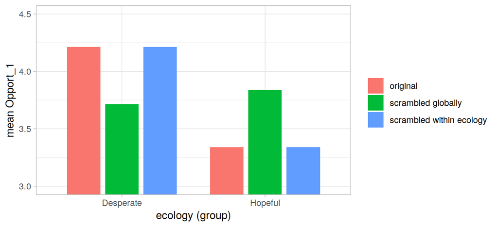

Figure 1: Within-group scrambling leaves the group means untouched; global scrambling flattens them.

```r
bind_rows(
  group_means(williams,  "original"),
  group_means(w_global,  "scrambled globally"),
  group_means(w_grouped, "scrambled within ecology")
) |>
  ggplot(aes(x = ecology, y = mean_opport, fill = version)) +
  geom_col(position = position_dodge(width = 0.8), width = 0.7) +
  coord_cartesian(ylim = c(3, 4.5)) +
  labs(x = "ecology (group)", y = "mean Opport_1", fill = NULL)
```

### Combining the arguments

`.groups` and `.together` are independent and compose:

```r
set.seed(7)

williams |>
  scramble_variables(c(Opport_1, Opport_2),
                     .groups = "ecology",
                     .together = TRUE) |>
  select(subject, ecology, Opport_1, Opport_2) |>
  head(5)
```

| subject | ecology | Opport_1 | Opport_2 |
| --- | --- | --- | --- |
| A30MP4LXV4MIFD | Hopeful | 4 | 2 |
| A16X5FB3HAFCKN | Desperate | 4 | 5 |
| A1E9D1OT9VJYDZ | Desperate | 4 | 4 |
| A16FPOYD7566WI | Hopeful | 2 | 3 |
| A11NOTVHWST7Y3 | Desperate | 5 | 6 |

Read that call out loud: *move the `Opport_1`/`Opport_2` pairs around, but only within an ecology group, and keep each pair together.* That sentence is the whole API.

**A grouping column cannot also be a scrambled column**

`.groups` must name columns that are **not** in your selection. If you try to scramble `ecology` within `ecology`, you get an error — which is the right behaviour, but the message is easier to understand if you were expecting it.

## Row-wise scrambling

One more variant, useful for repeated measures in wide format. `.byrow = TRUE` shuffles values *within each row*, across the selected columns:

```r
set.seed(123)

df_items <- data.frame(
  id    = 1:3,
  day_1 = c(1, 4, 7),
  day_2 = c(2, 5, 8),
  day_3 = c(3, 6, 9)
)

scramble_variables(df_items, starts_with("day_"), .byrow = TRUE)
```

| id | day_1 | day_2 | day_3 |
| --- | --- | --- | --- |
| 1 | 3 | 1 | 2 |
| 2 | 5 | 4 | 6 |
| 3 | 8 | 9 | 7 |

Each participant keeps their own three values; the order in which they occurred is gone. That blinds a time trend without touching individual differences. The columns must be type-compatible, since values move between them.

## What survives what

Two words to pin down first, because both are used loosely elsewhere:

- a **block** is the set of columns you pass to a single `scramble_variables()` call — `c(age, Impuls_1)` in the examples above.
- a **cluster** is a grouping variable you scramble *within*, named in `.groups` — `ecology` above; elsewhere a clinic, a school, a participant, a country.

So the two correlation columns answer different questions: can the analyst still *build* the predictor (within the block), and can they still *relate* it to anything else (outside it).

Keep this table next to you during the exercise.

| Operation | Univariate distributions | Correlations *within* the scrambled block | Correlations *with other* columns | Cluster means |
| --- | --- | --- | --- | --- |
| `mask_variables()` | kept (names change only) | — | kept | kept |
| `scramble_variables()` | kept | **destroyed** | **destroyed** | destroyed |
| `... .together = TRUE` | kept | kept | **destroyed** | destroyed |
| `... .groups = "cluster"` | kept | **destroyed** | **destroyed** | **kept** |
| `... .together` + `.groups` | kept | kept | **destroyed** | **kept** |

The bottom row is the one most confirmatory blinding protocols want: the analyst can still compute composites, still compare clusters, still spot a broken site — and still cannot see the effect under test.

## Your turn

Open `03b_task_brief.qmd`. You will write your own blinding script from a written specification, so the decisions above are now yours to make.

## Further reading

- MacCoun, R., & Perlmutter, S. (2015). Blind analysis: Hide results to seek the truth. *Nature*, 526, 187–189. https://doi.org/10.1038/526187a
- Dutilh, G., Sarafoglou, A., & Wagenmakers, E.-J. (2019). Flexible yet fair: Blinding analyses in experimental psychology. *Synthese*. https://doi.org/10.1007/s11229-019-02456-7
- Package website: https://nthun.github.io/vazul/